# Introduction to Bayesian Statistical Modeling Workshop for Ecologists

2025-10-30

```r
# Load packages
library(rjags)
library(jagsUI)
library(coda)
library(MCMCvis)
library(ggmcmc)
library(ggplot2)
library(tidyverse)
library(gridExtra)
library(popbio)
```

## 1 Exercise: Mean estimation with JAGS

Suppose you have body mass (g) measurements of five passerine birds: 15.2, 14.8, 15.5, 14.9, 15.3. Assuming the body mass follows a normal distribution, estimate the mean body mass using a Bayesian approach.

```r
# JAGS code
mod_mean_exe <- "
model{
  # Likelihood
  for(i in 1:n){
    y[i] ~ dnorm(mu, tau) # JAGS uses precision (tau) instead of standard deviation (sigma); tau = 1/sigma^2
  }

  # Priors
  mu ~ dnorm(0, 0.0001)
  sigma ~ dunif(0, 100)
  tau <- 1/(sigma*sigma)   # pow(sigma,-2)
}#End model
"

# Bundle data
y <- c(15.2, 14.8, 15.5, 14.9, 15.3)
data <- list(y = y, n = length(y))

# Initial values
inits <- function(){list(mu = rnorm(1, 10, 1), sigma = runif(1, 0, 10))}

# Parameters monitored
params <- c("mu", "sigma", "tau")

# MCMC settings
ni <- 5000
nb <- 2000
nt <- 5
nc <- 3

# Running the model using JagsUI
out_mean_exe <- jagsUI(data = data, inits = inits, parameters.to.save = params,
                       model.file = textConnection(mod_mean_exe), n.chains = nc, n.thin = nt,
                       n.iter = ni, n.burnin = nb, verbose = FALSE)

# Print output
print(out_mean_exe, digits = 3)
```

```
## JAGS output for model '5', generated by jagsUI.
## Estimates based on 3 chains of 5000 iterations,
## adaptation = 100 iterations (sufficient),
## burn-in = 2000 iterations and thin rate = 5,
## yielding 1800 total samples from the joint posterior.
## MCMC ran for 0.001 minutes at time 2025-10-30 21:56:40.712677.
##
##            mean    sd   2.5%    50%  97.5% overlap0 f  Rhat n.eff
## mu       15.137 0.351 14.689 15.135 15.664    FALSE 1 1.115   824
## sigma     0.476 0.550  0.190  0.370  1.172    FALSE 1 1.219   187
## tau       8.971 7.097  0.728  7.289 27.774    FALSE 1 1.000  1800
## deviance  4.013 3.643  0.741  2.959 12.480    FALSE 1 1.058   260
##
## **WARNING** Rhat values indicate convergence failure.
## Rhat is the potential scale reduction factor (at convergence, Rhat=1).
## For each parameter, n.eff is a crude measure of effective sample size.
##
## overlap0 checks if 0 falls in the parameter's 95% credible interval.
## f is the proportion of the posterior with the same sign as the mean;
## i.e., our confidence that the parameter is positive or negative.
##
## DIC info: (pD = var(deviance)/2)
## pD = 6.6 and DIC = 10.604
## DIC is an estimate of expected predictive error (lower is better).
```

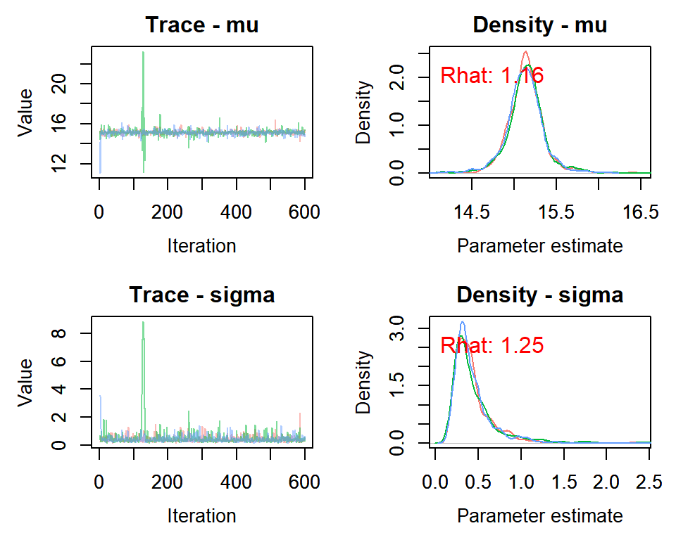

```r
# Convergence diagnostics plots with MCMCvis
# Trace and density plots
samples <- out_mean_exe$samples
MCMCtrace(samples, params = c("mu", "sigma"), ind = TRUE, Rhat = TRUE, pdf = FALSE)
```

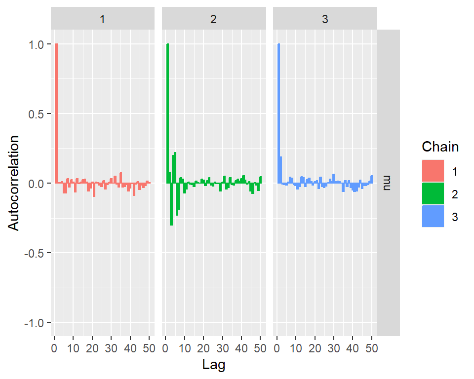

```r
# Use the "ggmcmc" package for autocorrelation plot
out_mean_exe_mcmc <- mcmc.list(out_mean_exe$samples) #convert the output to 'mcmc' list
out_mean_exe_gg <- ggs(out_mean_exe_mcmc) #convert the list to ggmcmc format
ggs_autocorrelation(out_mean_exe_gg, family=c("mu"))
```

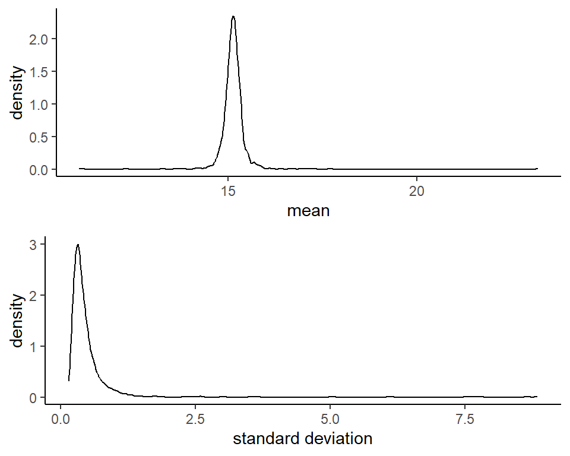

```r
# Posterior density plots for model parameters
fig1 <- ggplot(data=NULL, aes_q(x = out_mean_exe$sims.list$mu)) +
  geom_density() +
  xlab("mean") +
  theme_classic()

fig2 <- ggplot(data=NULL, aes_q(x = out_mean_exe$sims.list$sigma)) +
  geom_density() +
  xlab("standard deviation") +
  theme_classic()

grid.arrange(fig1, fig2, nrow = 2)
```

## 2 Exercise: General Linear Model

Fit a model using the data in “coha.csv” to assess how body mass differs between first year (FY) and after first year (AFY) Cooper’s hawks, adjusting for wing length and tarsus length.

```r
# Read data
coha <- read.csv("coha.csv", header = T)

# JAGS code
mod_lm_exe <- "model {
# Priors
 for(k in 1:2) {
  alpha[k] ~ dnorm(0, 0.0001)
 }

 for(k in 1:2) {
  beta[k] ~ dnorm(0, 0.0001)
 }

 sigma ~ dunif(0, 100)
 tau <- pow(sigma, -2)

# Likelihood
 for (i in 1:n) {
    y[i] ~ dnorm(mu[i], tau)
    mu[i] <- alpha[g[i]] + beta[1]*x1[i] + beta[2]*x2[i]
 }
}
"

# Bundle data
y <- coha$mass
g <- as.numeric(factor(coha$age))
x1 <- as.numeric(scale(coha$wing)) #standardized
x2 <- as.numeric(scale(coha$tarsus)) #standardized

data <- list(y = y, g = g, x1 = x1, x2 = x2, n = length(y))

# Initial values
inits <- function(){list(alpha = rnorm(2, 0, 1), beta = rnorm(2, 0, 1),
                         sigma = runif(1, 0, 10))}

# Parameters monitored
params <- c("alpha", "beta", "sigma")

# MCMC settings
ni <- 5000
nb <- 2000
nt <- 5
nc <- 3

# Running the model using JagsUI
out_lm_exe <- jagsUI(data = data, inits = inits, parameters.to.save = params,
                     model.file = textConnection(mod_lm_exe), n.chains = nc, n.thin = nt,
                     n.iter = ni, n.burnin = nb, verbose = FALSE)

# Print output
print(out_lm_exe, digits = 3)
```

```
## JAGS output for model '6', generated by jagsUI.
## Estimates based on 3 chains of 5000 iterations,
## adaptation = 100 iterations (sufficient),
## burn-in = 2000 iterations and thin rate = 5,
## yielding 1800 total samples from the joint posterior.
## MCMC ran for 0.004 minutes at time 2025-10-30 21:56:41.726512.
##
##             mean    sd    2.5%     50%   97.5% overlap0     f  Rhat n.eff
## alpha[1] 477.194 9.016 458.440 477.636 493.705    FALSE 1.000 1.003   639
## alpha[2] 447.558 9.131 429.364 447.845 465.017    FALSE 1.000 1.000  1800
## beta[1]   -3.319 7.818 -18.936  -3.267  12.101     TRUE 0.667 1.000  1800
## beta[2]   13.813 7.415  -0.730  13.800  28.318     TRUE 0.967 1.001  1140
## sigma     33.657 5.072  25.440  32.932  45.325    FALSE 1.000 1.003   826
## deviance 294.319 3.853 289.146 293.609 303.708    FALSE 1.000 1.001  1800
##
## Successful convergence based on Rhat values (all < 1.1).
## Rhat is the potential scale reduction factor (at convergence, Rhat=1).
## For each parameter, n.eff is a crude measure of effective sample size.
##
## overlap0 checks if 0 falls in the parameter's 95% credible interval.
## f is the proportion of the posterior with the same sign as the mean;
## i.e., our confidence that the parameter is positive or negative.
##
## DIC info: (pD = var(deviance)/2)
## pD = 7.4 and DIC = 301.743
## DIC is an estimate of expected predictive error (lower is better).
```

## 3 Exercise: Generalized Linear Model (Logistic regression)

The file “coha1.csv”” contains data on Cooper’s hawk presence (1) and absence (0) from a single visit to 35 nests. Data include prey abundance and a habitat covariate with categories residential or park (1) and industrial (2). Fit an appropriate model to examine the effects of these two covariates on Cooper’s hawk presence.

```r
# Read data
coha1 <- read.csv("coha1.csv", header = T)

# JAGS code
mod_logistic_exe <- "model {
# Priors
 for(k in 1:2) {
  alpha[k] ~ dnorm(0, 0.0001)
 }

 for(k in 1:2) {
  beta[k] ~ dnorm(0, 0.0001)
 }

# Likelihood
 for (i in 1:n) {
    y[i] ~ dbern(p[i])
    logit(p[i]) <- alpha[g[i]] + beta[g[i]]*x[i] # a model with interaction
 }
}
"

# Bundle data
y <- coha1$presence
g <- coha1$habitat
x <- as.numeric(scale(coha1$prey)) # standardized

data <- list(y = y, g = g, x = x, n = length(y))

# Initial values
inits <- function(){list(alpha = rnorm(2, 0, 1), beta = rnorm(2, 0, 1))}

# Parameters monitored
params <- c("alpha", "beta")

#MCMC settings
ni <- 5000
nb <- 2000
nt <- 5
nc <- 3

# Running the model using JagsUI
out_logistic_exe <- jagsUI(data = data, inits = inits, parameters.to.save = params,
                           model.file = textConnection(mod_logistic_exe), n.chains = nc, n.thin = nt,
                           n.iter = ni, n.burnin = nb, verbose = FALSE)

# Print output
print(out_logistic_exe, digits = 3)
```

```
## JAGS output for model '7', generated by jagsUI.
## Estimates based on 3 chains of 5000 iterations,
## adaptation = 100 iterations (sufficient),
## burn-in = 2000 iterations and thin rate = 5,
## yielding 1800 total samples from the joint posterior.
## MCMC ran for 0.01 minutes at time 2025-10-30 21:56:42.037245.
##
##            mean    sd   2.5%    50%  97.5% overlap0     f  Rhat n.eff
## alpha[1]  0.204 0.462 -0.689  0.193  1.118     TRUE 0.661 1.000  1800
## alpha[2] -0.373 0.574 -1.530 -0.366  0.740     TRUE 0.738 1.000  1800
## beta[1]  -0.073 0.602 -1.295 -0.071  1.061     TRUE 0.551 1.001  1284
## beta[2]  -0.216 0.500 -1.197 -0.217  0.722     TRUE 0.673 1.001  1151
## deviance 53.538 3.045 49.820 52.867 61.447    FALSE 1.000 1.001  1800
##
## Successful convergence based on Rhat values (all < 1.1).
## Rhat is the potential scale reduction factor (at convergence, Rhat=1).
## For each parameter, n.eff is a crude measure of effective sample size.
##
## overlap0 checks if 0 falls in the parameter's 95% credible interval.
## f is the proportion of the posterior with the same sign as the mean;
## i.e., our confidence that the parameter is positive or negative.
##
## DIC info: (pD = var(deviance)/2)
## pD = 4.6 and DIC = 58.175
## DIC is an estimate of expected predictive error (lower is better).
```

## 4 Exercise: Generalized Linear Model (Poisson regression)

The file “coha2.csv” contains data on Cooper’s hawk brood counts from 25 nests. For each nesting territory, the maximum count observed from three surveys is recorded as the brood size. The data also the age of the female breeder (FY = 1 year old, and AFY > 1 year old) and the distance in meters to the nearest adjacent other occupied Cooper’s hawk nest. Fit an appropriate model to evaluate how brood size relates to female breeder age and nearest neighbor distance.

```r
# Read data
coha2 <- read.csv("coha2.csv", header = T)

# JAGS code
mod_poisson_exe <- "model {
# Priors
 for(k in 1:2) {
  alpha[k] ~ dnorm(0, 0.0001)
 }

 beta ~ dnorm(0, 0.0001)

# Likelihood
 for (i in 1:n) {
    y[i] ~ dpois(lambda[i])
    log(lambda[i]) <- alpha[g[i]] + beta*x[i] #Additive model
 }
}
"

# Bundle data
y <- coha2$fledge
g <- as.numeric(factor(coha2$agef))
x <- as.numeric(scale(coha2$nnd)) # standardized

data <- list(y = y, g = g, x = x, n = length(y))

# Initial values
inits <- function(){list(alpha = rnorm(2, 0, 1), beta = rnorm(1, 0, 1))}

# Parameters monitored
params <- c("alpha", "beta")

#MCMC settings
ni <- 5000
nb <- 2000
nt <- 5
nc <- 3

# Running the model using JagsUI
out_poisson_exe <- jagsUI(data = data, inits = inits, parameters.to.save = params,
                          model.file = textConnection(mod_poisson_exe), n.chains = nc, n.thin = nt,
                          n.iter = ni, n.burnin = nb, verbose = FALSE)

# Print output
print(out_poisson_exe, digits = 3)
```

```
## JAGS output for model '8', generated by jagsUI.
## Estimates based on 3 chains of 5000 iterations,
## adaptation = 100 iterations (sufficient),
## burn-in = 2000 iterations and thin rate = 5,
## yielding 1800 total samples from the joint posterior.
## MCMC ran for 0.014 minutes at time 2025-10-30 21:56:42.696094.
##
##            mean    sd   2.5%    50%  97.5% overlap0     f  Rhat n.eff
## alpha[1]  0.164 0.229 -0.313  0.175  0.582     TRUE 0.775 1.005   460
## alpha[2]  0.735 0.217  0.304  0.745  1.146    FALSE 1.000 1.004   443
## beta      0.047 0.163 -0.278  0.047  0.366     TRUE 0.612 1.003   993
## deviance 80.731 2.463 77.915 80.130 87.284    FALSE 1.000 1.005   591
##
## Successful convergence based on Rhat values (all < 1.1).
## Rhat is the potential scale reduction factor (at convergence, Rhat=1).
## For each parameter, n.eff is a crude measure of effective sample size.
##
## overlap0 checks if 0 falls in the parameter's 95% credible interval.
## f is the proportion of the posterior with the same sign as the mean;
## i.e., our confidence that the parameter is positive or negative.
##
## DIC info: (pD = var(deviance)/2)
## pD = 3 and DIC = 83.757
## DIC is an estimate of expected predictive error (lower is better).
```

## 5 Exercise: Linear Mixed Model

The R package “partR2” (Stoffel et al. 2021) includes a dataset on invertebrate biomass and 10 additional variables. For this exercise, use the variables population, precipitation, and year to fit an appropriate model that assesses the relationship between invertebrate biomass and the explanatory variables precipitation and year, while treating population as random effect. The dataset is provided in “biomass.csv”.

```r
# Read data
biomass <- read.csv("biomass.csv", header = T)

# JAGS code
mod_lmm_exe <- "model {
# Priors
 for(k in 1:K) {
  alpha[k] ~ dnorm(mu.alpha, tau.alpha)  # random intercepts
 }

 mu.alpha ~ dnorm(0, 0.0001) # mean hyperparameter for random intercepts
 sigma.alpha ~ dunif(0, 100) # sd hyperparameter for random intercepts
 tau.alpha <- pow(sigma.alpha, -2)

 for(k in 1:2) {
  beta[k] ~ dnorm(0, 0.0001)
 }

 sigma ~ dunif(0, 100) # Residual sd
 tau <- pow(sigma, -2)

# Likelihood
 for (i in 1:n) {
    y[i] ~ dnorm(mu[i], tau)
    mu[i] <- alpha[g[i]] + beta[1]*x1[i] + beta[2]*x2[i]
 }
}
"

# Bundle data
y <- biomass$biomass
g <- biomass$population
x1 <- as.numeric(scale(biomass$precipitation)) # standardized
x2 <- as.numeric(scale(biomass$year)) # standardized
K <- length(unique(biomass$population))

data <- list(y = y, g = g, x1 = x1, x2 = x2, n = length(y), K = K)

# Initial values
inits <- function(){list(mu.alpha = rnorm(1, 0, 1), beta = rnorm(2, 0, 1),
                         sigma.alpha = runif(1, 0, 10), sigma = runif(1, 0, 10))}

# Parameters monitored
params <- c("mu.alpha", "sigma.alpha", "beta", "sigma", "alpha")

#MCMC settings
ni <- 5000
nb <- 2000
nt <- 5
nc <- 3

# Running the model using JagsUI
out_lmm_exe <- jagsUI(data = data, inits = inits, parameters.to.save = params,
                      model.file = textConnection(mod_lmm_exe), n.chains = nc, n.thin = nt,
                      n.iter = ni, n.burnin = nb, verbose = FALSE)

# Print output
print(out_lmm_exe, digits = 3)
```

```
## JAGS output for model '9', generated by jagsUI.
## Estimates based on 3 chains of 5000 iterations,
## adaptation = 100 iterations (sufficient),
## burn-in = 2000 iterations and thin rate = 5,
## yielding 1800 total samples from the joint posterior.
## MCMC ran for 0.02 minutes at time 2025-10-30 21:56:43.575376.
##
##                mean    sd    2.5%     50%   97.5% overlap0     f  Rhat n.eff
## mu.alpha     39.853 0.229  39.415  39.861  40.311    FALSE 1.000 1.000  1800
## sigma.alpha   0.927 0.192   0.626   0.902   1.375    FALSE 1.000 1.002   957
## beta[1]       1.118 0.089   0.945   1.118   1.293    FALSE 1.000 1.000  1800
## beta[2]       0.223 0.086   0.053   0.223   0.389    FALSE 0.995 1.000  1800
## sigma         1.214 0.065   1.092   1.210   1.351    FALSE 1.000 1.002  1633
## alpha[1]     41.284 0.365  40.609  41.265  42.023    FALSE 1.000 1.001   939
## alpha[2]     39.196 0.345  38.515  39.202  39.838    FALSE 1.000 1.001  1053
## alpha[3]     39.587 0.354  38.879  39.589  40.277    FALSE 1.000 1.000  1800
## alpha[4]     39.473 0.351  38.769  39.467  40.160    FALSE 1.000 1.000  1800
## alpha[5]     38.812 0.370  38.070  38.809  39.545    FALSE 1.000 1.003   612
## alpha[6]     41.042 0.357  40.362  41.042  41.750    FALSE 1.000 0.999  1800
## alpha[7]     39.561 0.350  38.884  39.551  40.226    FALSE 1.000 1.000  1800
## alpha[8]     39.978 0.375  39.279  39.969  40.738    FALSE 1.000 1.004  1800
## alpha[9]     40.066 0.340  39.393  40.068  40.708    FALSE 1.000 1.002  1800
## alpha[10]    38.747 0.359  38.066  38.737  39.457    FALSE 1.000 0.999  1800
## alpha[11]    40.195 0.354  39.526  40.190  40.865    FALSE 1.000 0.999  1800
## alpha[12]    40.180 0.353  39.496  40.178  40.887    FALSE 1.000 1.000  1800
## alpha[13]    40.750 0.360  40.065  40.735  41.469    FALSE 1.000 1.001  1608
## alpha[14]    40.816 0.368  40.064  40.812  41.545    FALSE 1.000 1.002   921
## alpha[15]    40.167 0.348  39.490  40.159  40.884    FALSE 1.000 1.001  1586
## alpha[16]    39.905 0.350  39.239  39.912  40.599    FALSE 1.000 1.000  1800
## alpha[17]    38.950 0.363  38.244  38.943  39.681    FALSE 1.000 1.000  1800
## alpha[18]    38.919 0.349  38.259  38.914  39.603    FALSE 1.000 1.000  1800
## alpha[19]    40.628 0.357  39.925  40.622  41.340    FALSE 1.000 1.000  1800
## alpha[20]    38.856 0.362  38.176  38.860  39.536    FALSE 1.000 1.004   550
## deviance    643.320 7.025 631.075 642.831 658.486    FALSE 1.000 1.001   960
##
## Successful convergence based on Rhat values (all < 1.1).
## Rhat is the potential scale reduction factor (at convergence, Rhat=1).
## For each parameter, n.eff is a crude measure of effective sample size.
##
## overlap0 checks if 0 falls in the parameter's 95% credible interval.
## f is the proportion of the posterior with the same sign as the mean;
## i.e., our confidence that the parameter is positive or negative.
##
## DIC info: (pD = var(deviance)/2)
## pD = 24.6 and DIC = 667.968
## DIC is an estimate of expected predictive error (lower is better).
```

## 6 Exercise: GLMMs

The file “shrike.csv” contains count of red-backed shrike over 25 years in 6 different populations. Examine population trends while accounting for variation among populations random effects.

```r
# Read data
shrike <- read.csv("shrike.csv", header = T)

# JAGS code
mod_glmm_exe <- "model {
# Priors
 for(k in 1:K) {
  alpha[k] ~ dnorm(mu.alpha, tau.alpha)  # random intercepts
 }

 mu.alpha ~ dnorm(0, 0.0001) # mean hyperparameter for random intercepts
 sigma.alpha ~ dunif(0, 100) # sd hyperparameter for random intercepts
 tau.alpha <- pow(sigma.alpha, -2)

  beta ~ dnorm(0, 0.0001)

 sigma ~ dunif(0, 100) # Residual sd
 tau <- pow(sigma, -2)

# Likelihood
 for (i in 1:n) {
    y[i] ~ dpois(lambda[i])
    log(lambda[i]) <- alpha[g[i]] + beta*x[i]
 }
}
"

# Bundle data
y <- shrike$count
g <- shrike$pop
x <- as.numeric(scale(shrike$year)) # standardized
K <- length(unique(shrike$pop))

data <- list(y = y, g = g, x = x, n = length(y), K = K)

# Initial values
inits <- function(){list(mu.alpha = rnorm(1, 0, 1), beta = rnorm(1, 0, 1),
                         sigma.alpha = runif(1, 0, 10), sigma = runif(1, 0, 10))}

# Parameters monitored
params <- c("mu.alpha", "sigma.alpha", "beta", "sigma", "alpha")

#MCMC settings
ni <- 5000
nb <- 2000
nt <- 5
nc <- 3

# Running the model using JagsUI
out_glmm_exe <- jagsUI(data = data, inits = inits, parameters.to.save = params,
                       model.file = textConnection(mod_glmm_exe), n.chains = nc, n.thin = nt,
                       n.iter = ni, n.burnin = nb, verbose = FALSE)

# Print output
print(out_glmm_exe, digits = 3)
```

```
## JAGS output for model '10', generated by jagsUI.
## Estimates based on 3 chains of 5000 iterations,
## adaptation = 100 iterations (sufficient),
## burn-in = 2000 iterations and thin rate = 5,
## yielding 1800 total samples from the joint posterior.
## MCMC ran for 0.068 minutes at time 2025-10-30 21:56:44.83928.
##
##                 mean     sd     2.5%      50%    97.5% overlap0 f  Rhat n.eff
## mu.alpha       3.707  0.253    3.200    3.714    4.174    FALSE 1 1.003  1672
## sigma.alpha    0.541  0.288    0.249    0.465    1.337    FALSE 1 1.003  1800
## beta          -0.703  0.013   -0.729   -0.703   -0.679    FALSE 1 1.001  1800
## sigma         50.598 28.378    2.919   50.430   97.306    FALSE 1 1.001  1409
## alpha[1]       3.351  0.034    3.285    3.351    3.417    FALSE 1 0.999  1800
## alpha[2]       3.995  0.025    3.945    3.995    4.046    FALSE 1 1.001  1800
## alpha[3]       4.042  0.025    3.994    4.041    4.092    FALSE 1 1.001  1800
## alpha[4]       4.129  0.024    4.080    4.130    4.175    FALSE 1 1.002   837
## alpha[5]       3.333  0.035    3.262    3.334    3.402    FALSE 1 1.000  1800
## alpha[6]       3.455  0.033    3.392    3.456    3.521    FALSE 1 1.001  1301
## deviance    1134.498  3.796 1129.033 1133.797 1143.773    FALSE 1 1.001  1800
##
## Successful convergence based on Rhat values (all < 1.1).
## Rhat is the potential scale reduction factor (at convergence, Rhat=1).
## For each parameter, n.eff is a crude measure of effective sample size.
##
## overlap0 checks if 0 falls in the parameter's 95% credible interval.
## f is the proportion of the posterior with the same sign as the mean;
## i.e., our confidence that the parameter is positive or negative.
##
## DIC info: (pD = var(deviance)/2)
## pD = 7.2 and DIC = 1141.708
## DIC is an estimate of expected predictive error (lower is better).
```

## 7 Exercise: Single Season Occupancy Model

The file “coha3.csv”” contains data on Cooper’s hawk presence (1) and absence (0) from three visits to 35 nests. The dataset includes prey abundance and a habitat covariate with categories residential or park (1) and industrial (2). Fit an appropriate model to evaluate how Cooper’s hawk presence and detection probabilities relate to prey abundance and habitat type.

```r
# Read data
coha3 <- read.csv("coha3.csv", header = T)

#JAGS code
mod_occ_exe <- "model {
# Priors
for(k in 1:2){
 beta0[k] ~ dunif(-10, 10) #dnorm(0, 1e-6)
}

 beta ~ dunif(-10, 10) #dnorm(0, 1e-6)

 alpha0 ~ dunif(-10, 10) #dnorm(0, 1e-6)

# Likelihood
   for (i in 1:R){
        #Ecological process
        z[i] ~ dbern(psi[i])
        logit(psi[i]) <- beta0[g[i]] + beta*x[i]
        for (j in 1:T){
            #Observation process
            y[i,j] ~ dbern(pe[i,j])
            pe[i,j] <- z[i]*p[i,j]  # Can only be detected if z=1
            logit(p[i,j]) <- alpha0
        }
    }
}
"

# Bundle data
y <- coha3[,2:4]
g <- coha3$habitat
x <- as.numeric(scale(coha3$prey)) # standardized
R <- nrow(y)
T <- ncol(y)

data <- list(y = y, g = g, x = x, R = R, T = T)

# Initial values
zst <- apply(y, 1, max) # initial values for true/latent states
inits <- function(){list(beta0 = rnorm(2, 0, 1), beta = rnorm(1, 0, 1),
                         alpha0 = rnorm(1, 0, 1),
                         z = zst)}

# Parameters monitored
params <- c("beta0", "beta", "alpha0")

#MCMC settings
ni <- 5000
nb <- 2000
nt <- 5
nc <- 3

# Running the model using JagsUI
out_occ_exe <- jagsUI(data = data, inits = inits, parameters.to.save = params,
                      model.file = textConnection(mod_occ_exe), n.chains = nc, n.thin = nt,
                      n.iter = ni, n.burnin = nb, verbose = FALSE)

# Print output
print(out_occ_exe, digits = 3)
```

```
## JAGS output for model '11', generated by jagsUI.
## Estimates based on 3 chains of 5000 iterations,
## adaptation = 100 iterations (sufficient),
## burn-in = 2000 iterations and thin rate = 5,
## yielding 1800 total samples from the joint posterior.
## MCMC ran for 0.018 minutes at time 2025-10-30 21:56:48.968668.
##
##             mean    sd   2.5%     50%   97.5% overlap0     f  Rhat n.eff
## beta0[1]   4.472 1.854  1.542   4.211   8.948    FALSE 1.000 1.001  1097
## beta0[2]   5.967 2.210  1.777   6.056   9.677    FALSE 0.999 1.006   299
## beta      -3.449 1.842 -6.740  -3.530   0.018     TRUE 0.974 1.008   236
## alpha0     1.113 0.259  0.615   1.119   1.622    FALSE 1.000 1.003   806
## deviance 111.373 7.625 97.143 107.916 129.770    FALSE 1.000 1.000  1800
##
## Successful convergence based on Rhat values (all < 1.1).
## Rhat is the potential scale reduction factor (at convergence, Rhat=1).
## For each parameter, n.eff is a crude measure of effective sample size.
##
## overlap0 checks if 0 falls in the parameter's 95% credible interval.
## f is the proportion of the posterior with the same sign as the mean;
## i.e., our confidence that the parameter is positive or negative.
##
## DIC info: (pD = var(deviance)/2)
## pD = 29.1 and DIC = 140.477
## DIC is an estimate of expected predictive error (lower is better).
```

## 8 Exercise: State-Space Model for Population Counts

```r
# Read data
ele <- read.csv("elephant.csv", header = T)

# JAGS code
mod_ss_exe <- "model {
# Priors
N.est[1] ~ dunif(5, 10)
mu.lambda ~ dunif(0, 10)
sigma.lambda ~ dunif(0,10)
tau.lambda <- pow(sigma.lambda, -2)

sigma.obs ~ dunif(0,10)
tau.obs <- pow(sigma.obs, -2)

# Likelihood
   #State process
   for (t in 1:(T-1)){
        lambda[t] ~ dnorm(mu.lambda, tau.lambda)
        N.est[t+1] <- N.est[t]*lambda[t]
   }
   #Observation process
   for (t in 1:T){
        y[t] ~ dnorm(N.est[t], tau.obs)
    }
}
"

# Bundle data
y <- ele$count/1000  # rescale the data by a factor of 0.001
T <- length(y)

data <- list(y = y, T = T)

# Initial values
inits <- function(){list(mu.lambda = runif(1, 0.1, 2), sigma.lambda = runif(1, 0, 5),
                         sigma.obs = runif(1, 0, 5),
                         N.est = c(runif(1,5,10), rep(NA,(T-1))))}

# Parameters monitored
params <- c("mu.lambda", "sigma.lambda", "sigma.obs", "N.est")

#MCMC settings
ni <- 5000
nb <- 2000
nt <- 5
nc <- 3

# Running the model using JagsUI
out_ss_exe <- jagsUI(data = data, inits = inits, parameters.to.save = params,
                     model.file = textConnection(mod_ss_exe), n.chains = nc, n.thin = nt,
                     n.iter = ni, n.burnin = nb, verbose = FALSE)

# Print output
print(out_ss_exe, digits = 3)
```

```
## JAGS output for model '12', generated by jagsUI.
## Estimates based on 3 chains of 5000 iterations,
## adaptation = 100 iterations (sufficient),
## burn-in = 2000 iterations and thin rate = 5,
## yielding 1800 total samples from the joint posterior.
## MCMC ran for 0.009 minutes at time 2025-10-30 21:56:50.088441.
##
##                mean     sd    2.5%    50%  97.5% overlap0     f  Rhat n.eff
## mu.lambda     1.017  0.014   0.990  1.016  1.044    FALSE 1.000 1.002  1800
## sigma.lambda  0.062  0.017   0.031  0.061  0.097    FALSE 1.000 1.028    81
## sigma.obs     0.261  0.119   0.079  0.247  0.513    FALSE 1.000 1.043    56
## N.est[1]      7.418  0.223   6.959  7.425  7.876    FALSE 1.000 1.007   664
## N.est[2]      7.484  0.219   7.078  7.460  7.951    FALSE 1.000 1.010   233
## N.est[3]      7.994  0.213   7.540  8.009  8.403    FALSE 1.000 1.014   169
## N.est[4]      8.433  0.305   7.737  8.489  8.905    FALSE 1.000 1.021   108
## N.est[5]      8.104  0.244   7.562  8.122  8.543    FALSE 1.000 1.015   138
## N.est[6]      7.200  0.274   6.746  7.164  7.773    FALSE 1.000 1.027    78
## N.est[7]      7.466  0.219   6.993  7.492  7.859    FALSE 1.000 1.015   137
## N.est[8]      7.092  0.233   6.713  7.055  7.633    FALSE 1.000 1.018   125
## N.est[9]      7.310  0.206   6.901  7.308  7.733    FALSE 1.000 1.005   876
## N.est[10]     7.430  0.200   7.006  7.434  7.838    FALSE 1.000 1.007   424
## N.est[11]     7.350  0.211   6.934  7.341  7.814    FALSE 1.000 1.003   860
## N.est[12]     7.481  0.208   7.070  7.469  7.905    FALSE 1.000 1.000  1800
## N.est[13]     7.630  0.211   7.198  7.631  8.070    FALSE 1.000 1.002  1800
## N.est[14]     7.795  0.217   7.346  7.792  8.242    FALSE 1.000 1.002  1800
## N.est[15]     7.858  0.206   7.450  7.845  8.305    FALSE 1.000 1.007   392
## N.est[16]     8.066  0.211   7.644  8.066  8.497    FALSE 1.000 1.010  1800
## N.est[17]     8.297  0.220   7.854  8.293  8.756    FALSE 1.000 1.006   683
## N.est[18]     8.435  0.214   8.017  8.422  8.878    FALSE 1.000 1.010   218
## N.est[19]     8.804  0.217   8.361  8.811  9.232    FALSE 1.000 1.004  1800
## N.est[20]     9.017  0.228   8.516  9.042  9.432    FALSE 1.000 1.011   193
## N.est[21]     8.634  0.285   8.209  8.578  9.294    FALSE 1.000 1.029    76
## N.est[22]     9.323  0.221   8.901  9.311  9.814    FALSE 1.000 1.009  1377
## N.est[23]    10.238  0.314   9.488 10.303 10.708    FALSE 1.000 1.008   251
## deviance     -2.520 22.127 -50.016  0.900 30.790     TRUE 0.481 1.093    32
##
## Successful convergence based on Rhat values (all < 1.1).
## Rhat is the potential scale reduction factor (at convergence, Rhat=1).
## For each parameter, n.eff is a crude measure of effective sample size.
##
## overlap0 checks if 0 falls in the parameter's 95% credible interval.
## f is the proportion of the posterior with the same sign as the mean;
## i.e., our confidence that the parameter is positive or negative.
##
## DIC info: (pD = var(deviance)/2)
## pD = 229.1 and DIC = 226.59
## DIC is an estimate of expected predictive error (lower is better).
```

## 9 Exercise: Matrix Population Models

Construct a post-breeding female-based life-cycle graph and a population matrix for the Cooper’s hawk population using the parameter values below.

| Parameter | Value |
| --- | --- |
| Age at first breeding | 1 year |
| Juvenile (FY) survival | 0.2 |
| Adult (AFY) survival | 0.79 |
| FY Fecundity | 2.51 |
| AFY Fecundity | 3.25 |

Using the vital rates provided, determine the long-term population growth rate, stable age distribution and reproductive values for this population. Perform all calculations with the ‘popbio’ package in R.

```r
# Load package
library(popbio)

# Mean demographic estimates. Note FY = first-year, AFY = after-first-year.
S.fy <- 0.2
S.afy <- 0.79
F.fy<- 2.51
F.afy <- 3.25

stage <- c("FY", "AFY")

#Projection matrix - note that fecundity is reduced by 1/2 to convert to
#   females produced per female, assuming 50:50 sex ratio at fledging.
A <- matrix(c(S.fy*F.fy*0.5, S.afy*F.afy*0.5,
              S.fy, S.afy),nrow=2,ncol=2,byrow=T,dimnames=list(stage,stage))
print(A)
```

```
##        FY     AFY
## FY  0.251 1.28375
## AFY 0.200 0.79000
```

```r
# Asymptotic growth rate - dominant eigenvalue.
lambda(A)
```

```
## [1] 1.094417
```

```r
# Stable age/stage distribution - right eigenvector.
stable.stage(A)
```

```
##        FY       AFY
## 0.6035023 0.3964977
```

```r
# Reproductive value - left eigenvector.
reproductive.value(A)
```

```
##       FY      AFY
## 1.000000 4.217083
```

```r
# Sensitivity and elasticity analysis of vital rates. Note, need to rename
#   parameters to avoid overwriting.
tvr <- list(S1 = S.fy, S2 = S.afy,
            F1 = F.fy, F2 = F.afy)

tel <- expression(S1*F1*0.5, S2*F2*0.5,
                  S1, S2)

options(scipen=999) # turn it off the sci notation

x <- vitalsens(tel, tvr) # function to calculate sensitivity and elasticity
print(x)
```

```
##    estimate sensitivity elasticity
## S1     0.20  1.45124993 0.26520978
## S2     0.79  1.01793241 0.73479022
## F1     2.51  0.02652098 0.06082479
## F2     3.25  0.06882533 0.20438500
```

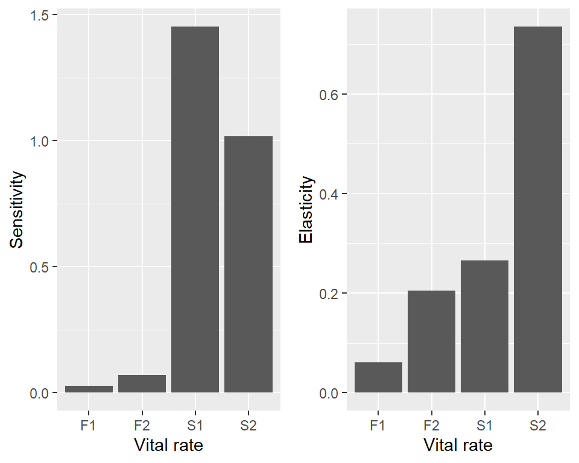

```r
# Sensitivity plot
fig1 <- ggplot(data = NULL,
               aes(x =rownames(x), y = x[,2])) + geom_bar(stat = "identity") +
  xlab("Vital rate") + ylab("Sensitivity")

#Elasticity plot
fig2 <- ggplot(data = NULL,
               aes(x =rownames(x), y = x[,3])) + geom_bar(stat = "identity") +
  xlab("Vital rate") + ylab("Elasticity")

grid.arrange(fig1, fig2, ncol = 2)
```